# eksamen_2021v

# Grunnleggende

## a) Bernoulli-prosess

La A være alle R-brukere i verden, og B være alle MatLab- brukere. Bruk følgende anslag på antallene: R: |A| = 2 000 000 MatLab: |B| = 4 000 000 Overlapp: |AB| = 400 000

### i.

**La p1 være andelen R-brukere som også er MatLab-brukere, og la p2 være andelen MatLab-brukere som også er R-brukere. Regn ut disse to tallene.**

Fordeling av R brukere som også er Matlab brukere: $\frac{AB}{A} = 0.2$

Fordeling av Matlab brukere som også er R brukere: $\frac{AB}{B} = 0.1$

### ii.

På den nye jobben din er det 15 R-brukere. La X være hvor mange av dem som også er MatLab-brukere, og la X $\thicksim$f(x). Finn a. f(x) b. E
$$X$$
c. Tegn sannsynlighetsfordelingen (pdf).

a: $f(x) \thicksim bin_{(15, \hspace{2mm} 0.2)}(x)$

b: $E[X] = 15 \cdot 0.2 = 3$

c:

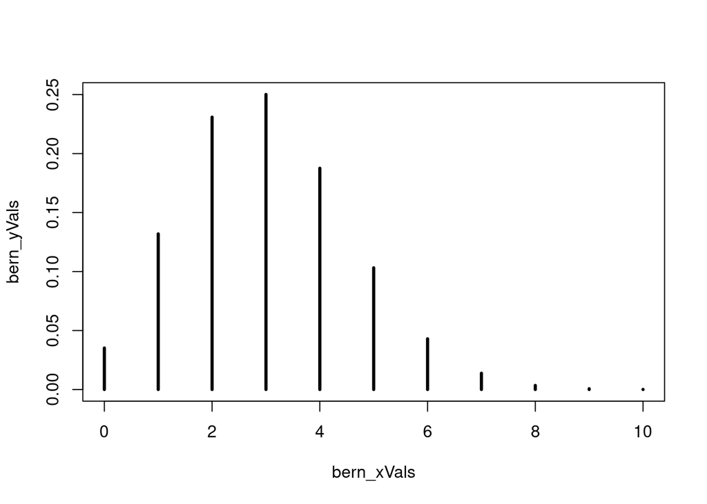

### iii.

Du er på konferanse for MatLab-brukere. La Y være antallet ikke-R-brukere du hilser på før du har hilst på 4 R-brukere, og la Y $\thicksim$g(y). Finn A. g(y) B. P(Y > 20) C. $\sigma$^2_Y .

a: $Y \thicksim g_{(4, \hspace{2mm} 0.1)}(x)$

b: $Y \thicksim g_{(4, \hspace{2mm} 0.1)}(20) = 0.7857378$

c: $\sigma_Y^2 = \frac{4 \cdot (1 - 0.1)}{0.1^2} = 360$

## b) Gaussisk prosess

### i.

X$\thicksim$f(x) er en kontinuerlig stokastisk variabel med E[X] = 4, $\sigma$X = 2. Bruk normaltilnærmingen til f(x) til å regne ut P(X $\leq$ 3).

X = $\Phi_{(4, 2)}(3)$ = 0.30853

### ii.

Y $\thicksim$ g(y) er en diskret stokastisk variabel med E[Y] = 4, $\sigma$Y = 2. Bruk normaltilnærmingen til g(y) til å regne ut P(Y $\leq$ 3).

Y = $\Phi_{(4, 2)}(3 + \frac{1}{2})$ = 0.4012937

## Sannsynlighetsfordelinger

### i.

**Hvorfor er ppois(1,$\lambda$) alltid større enn dpois(1,λ), uansett hvilken verdi du setter inn for $\lambda$?**

Fordi ppois er CDF og den er kummulativ, vil den alltid være høyere enn dpois ettersom den bare gjelder for én verdi

### ii.

R kommandoen for å regne ut P($-2 \leq X < 6$) er først å ta CDF av 6, for å så trekke i fra CDF av -2

```r
P_2_leq_X_l_6 = pt.scaled(6, 5, 7, 3) - pt.scaled(-2, 5, 7, 3)
P_2_leq_X_l_6
```

```
## [1] 0.3611537
```

### iii.

A. X̃= 7

B. $X_max \approx 1$

C. P ($X \leq 0$) = 0

### iv.

A. Ỹ̃ =2.5

B. $Y_max \approx 1.1$

C. P ($Y \leq 0$) = 0.09

# Inferens

## Bernoulli-prosess

**Du har spurt 200 tilfeldige nordmenn om de skal på naturferie i sommer (i motsetning til byferie eller ikke-ferie). 57 svarer at de skal på naturferie, 123 at de ikke skal, mens 20 har ikke svart.**

### i.

Fordi det er et boolsk valg mellom skal/skal ikke på naturferie så gir det ikke mening å ta med dem som ikke har svart, ettersom det ikke er et av valgene.

### ii.

```r
a_0 = 1
b_0 = 1

k = 57
l = 123

a_1 = a_0 + k
b_1 = b_0 + l
```

### iii.

$\pi = \beta_{(58, \hspace{2mm} 124)}$

## Gaussisk prosess

```
## [1] -1.387893 -0.927109 -4.962876  2.135971 -0.284439 13.543366  1.608963
## [8] -8.369690 -2.827972
```

```
## [1] 0.1587112
```

### i.

$\tau \thicksim \gamma_{(\frac{8}{2}, \frac{295.879206}{2})}(t)$ = $\tau \thicksim \gamma_{(4, 147.939603)}(t)$

$\mu = t_{(-0.1635199, 2.0271738, 8)}(x)$

$X_+ = t_{(-0.1635199, 6.4104863, 8)}(x)$

### ii.

$P(\sigma \leq 5) = P(\sigma^2 \leq 5^2) = P(\frac{1}{\sigma^2} \geq \frac{1}{5^2}) = P(\tau \geq 0.04)$

$P(\tau \geq 0.04) = 1 - \Gamma_{(4, 147.939603)}(0.04) = 0.1587112$

### iii.

$H_0$ blir da $P(\sigma \leq 5)$, og $H_1$ blir da $P(\sigma > 5)$ Hvis $\alpha$ er større enn $P(\sigma \leq 5)$ så forkaster vi $H_0$ til fordel for $H_1$

### vi.

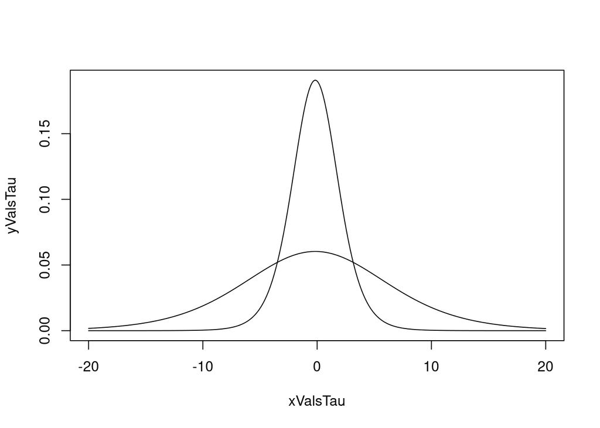

### v.

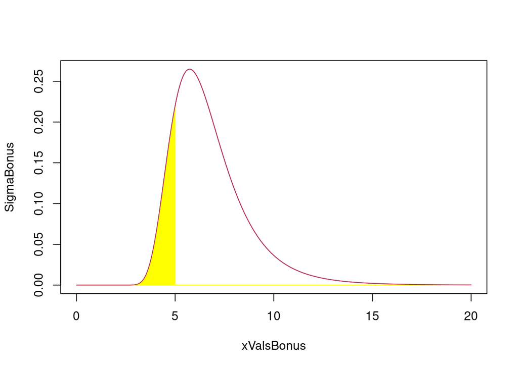

## c) Lineær regresjon

```
## (Intercept)   lin_reg_x
##   -3.206885    4.142698
```

```
##
## Call:
## lm(formula = lin_reg_y ~ lin_reg_x)
##
## Residuals:
##       Min        1Q    Median        3Q       Max
## -0.082852 -0.061479  0.008965  0.027098  0.109280
##
## Coefficients:
##             Estimate Std. Error t value Pr(>|t|)
## (Intercept) -3.20689    0.11747  -27.30 2.27e-08 ***
## lin_reg_x    4.14270    0.09521   43.51 8.84e-10 ***
## ---
## Signif. codes:  0 '***' 0.001 '**' 0.01 '*' 0.05 '.' 0.1 ' ' 1
##
## Residual standard error: 0.07321 on 7 degrees of freedom
## Multiple R-squared:  0.9963, Adjusted R-squared:  0.9958
## F-statistic:  1893 on 1 and 7 DF,  p-value: 8.844e-10
```

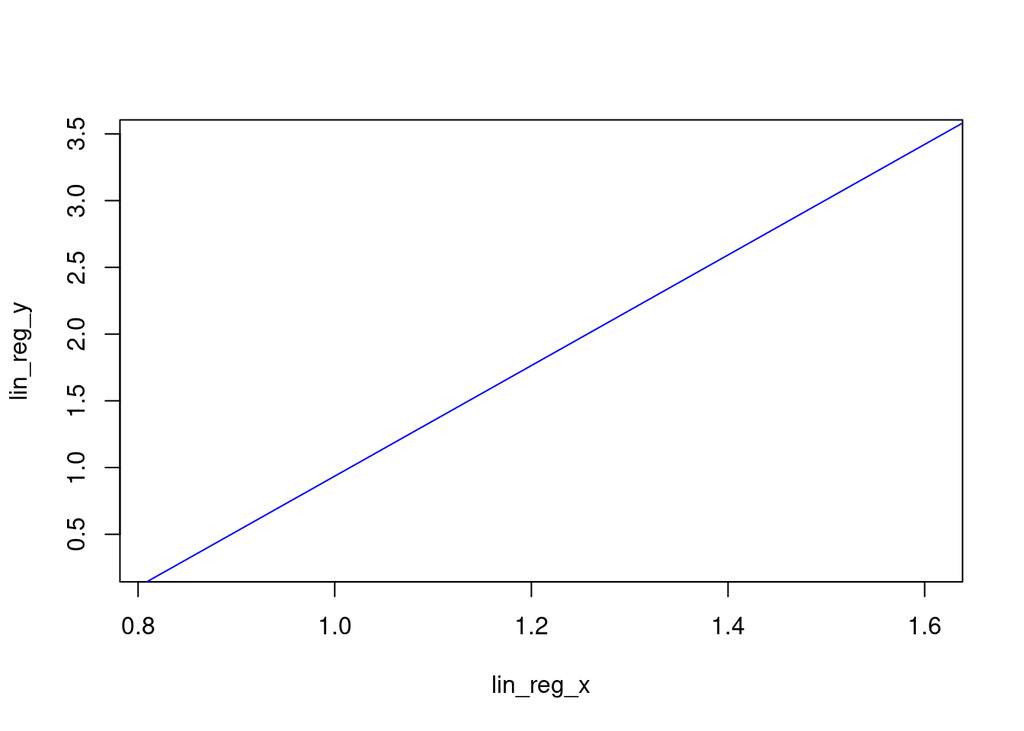

```
##       [,1]    [,2]
##  [1,]    1 0.81329
##  [2,]    1 0.90790
##  [3,]    1 1.00710
##  [4,]    1 1.10630
##  [5,]    1 1.20700
##  [6,]    1 1.30460
##  [7,]    1 1.40380
##  [8,]    1 1.50450
##  [9,]    1 1.60680
```

```
##          [,1]
##  [1,] 0.27161
##  [2,] 0.56686
##  [3,] 0.93231
##  [4,] 1.30620
##  [5,] 1.71050
##  [6,] 2.13620
##  [7,] 2.61760
##  [8,] 3.11510
##  [9,] 3.47670
```

```
##          [,1]     [,2]
## [1,]  9.00000 10.86129
## [2,] 10.86129 13.69868
```

```
##          [,1]      [,2]
## [1,]  2.57468 -2.041390
## [2,] -2.04139  1.691558
```

```
##          [,1]
## [1,] 16.13308
## [2,] 21.91860
```

```
##           [,1]
## [1,] -3.206885
## [2,]  4.142698
```

```
##         [,1]    [,2]    [,3]   [,4]   [,5]   [,6]   [,7]   [,8]   [,9]
## [1,] 0.27161 0.56686 0.93231 1.3062 1.7105 2.1362 2.6176 3.1151 3.4767
```

```
##           [,1]
## [1,] -3.206885
## [2,]  4.142698
```

```
##           [,1]     [,2]
## [1,] -3.206885 4.142698
```

```
##          [,1]
## [1,] 39.10274
```

```
##           [,1]      [,2]      [,3]     [,4]     [,5]     [,6]     [,7]     [,8]
## [1,] 0.1623298 0.5542705 0.9652261 1.376182 1.793352 2.197679 2.608635 3.025804
##          [,9]
## [1,] 3.449602
```

```
##          [,1]    [,2]
## [1,] 16.13308 21.9186
```

```
##          [,1]
## [1,] 39.06523
```

```
##            [,1]
## [1,] 0.03751401
```

```
##             [,1]
## [1,] 0.005359144
```

### i.

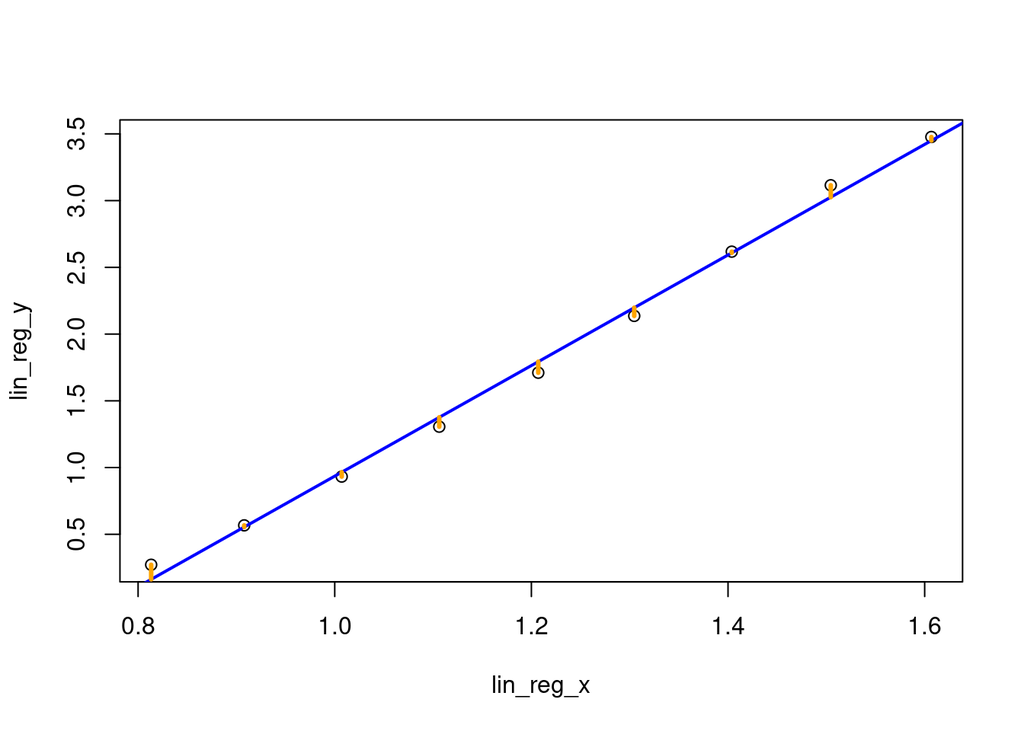

### iii.

```r
beta_reg = matrix(cbind(reg$coefficients[1], reg$coefficients[2]), ncol = 1, nrow=2)


n_reg_0 = length(lin_reg_x)
nu_0_reg = -2
SS_0_reg = 0

nu_1_reg = nu_0_reg + n_reg_0
SS_1_reg = SS_0_reg + SSe_reg


tau_reg = dgamma(nu_1_reg/2, SS_1_reg/2)

S_1_2_reg = SS_1_reg/nu_1_reg
S_1_reg = sqrt(S_1_2_reg)

b_reg = dt.scaled(beta_reg, S_1_2_reg, nu_1_reg)

SSx = sum(lin_reg_x^2) - (sum(lin_reg_x)^2 / length(lin_reg_x))
```

$\tau \gamma_{(3.5, \hspace{2mm} 0.018757)}$

$s_1^2 = \frac{0.037514}{7}$

$b \thicksim t_{(4.1426984,\hspace{2mm} 0.0952119, \hspace{2mm} 7)}$

$y(x) \thicksim t_{(-3.2068854 + 4.1426984, \hspace{2mm} 0.0732062 \cdot \sqrt{\frac{1}{9} + \frac{1}{0.5911708}(x - 1.20681)^2}, \hspace{2mm} 7)}$

$Y_+(x) \thicksim t_{(-3.2068854 + 4.1426984, \hspace{2mm} 0.0732062 \cdot \sqrt{1 + \frac{1}{9} + \frac{1}{0.5911708}(x - 1.20681)^2}, \hspace{2mm} 7)}$